# Problem Set 5: Trees, Forests, and Fairness in ML

Your mission for this problem set is to use your knowledge of tree-based methods and supervised learning to -- among other things! -- explore issues of fairness in machine learning (ML). Unlike in previous psets, where we were implementing algorithms from scratch, this pset will rely more heavily on sklearn. Unless explicitly noted otherwise, you are allowed (encouraged!) to make good use of this wonderful library.

This problem set will also rely on the resources provided by the [folktables](https://github.com/socialfoundations/folktables?tab=readme-ov-file) project. Before getting started, take some time to understand what folktables is about and how it can be used to benchmark ML algorithms in social science. If you don't understand the basics, this pset will be very challenging!!

Some resources you might find useful:

[Folktables paper](https://arxiv.org/abs/2108.04884)

[Folktables video](https://youtube.com/watch?v=KP7DhM_ahHI)

[PUMS_Data_Dictionary_2018](https://www2.census.gov/programssurveys/acs/tech_docs/pums/data_dict/PUMS_Data_Dictionary_2018.pdf)

[Fairness in ML](https://fairmlbook.org/classification.html)

```python
import numpy as np
import pandas as pd
import matplotlib.pyplot as plt
# !pip install folktables
import folktables
import seaborn as sns
```

## Part I: Setup of prediction task

### 1.1 Define the income prediction task

For this first question we are providing the code. Run it to download the data you'll be using throughout this problem set.

Begin by explaining what this prediction task is about and what is this code accomplishing:

- Where do the data come from
- What is the sample?
- What are we trying to predict?
- What are the features that we will be using?
- What is the "group" feature about?

```python
from folktables import ACSDataSource, generate_categories

def adult_filter(data):
    """Mimic the filters in place for Adult data.

    Adult documentation notes: Extraction was done by Barry Becker from
    the 1994 Census database. A set of reasonably clean records was extracted
    using the following conditions:
    ((AAGE>16) && (AGI>100) && (AFNLWGT>1)&& (HRSWK>0))
    """
    df = data
    df = df[df['AGEP'] > 16]
    df = df[df['PINCP'] > 100]
    df = df[df['WKHP'] > 0]
    df = df[df['PWGTP'] >= 1]
    return df

ACSIncome = folktables.BasicProblem(
    features=[
        'AGEP',
        'COW',
        'SCHL',
        'MAR',
        'POBP',
        'RELP',
        'WKHP',
        'SEX',
        'RAC1P',
    ],
    target='PINCP',
    target_transform=lambda x: x > 50000,
    group='RAC1P',
    preprocess=adult_filter,
    postprocess=lambda x: np.nan_to_num(x, -1),
)

data_source = ACSDataSource(survey_year='2018', horizon='1-Year', survey='person')
acs_data = data_source.get_data(states=["CA"], download=True)
definition_df = data_source.get_definitions(download=True)
categories = generate_categories(features=ACSIncome.features, definition_df=definition_df)
features, target, group = ACSIncome.df_to_pandas(acs_data)

feature_names = ACSIncome.features
target_name = ACSIncome.target
group_name = ACSIncome.group
```

*your answer here*

- Where do the data come from
  - from the American Community Survey (part of the US Census), the 2018 1-year-summary version for the state of California
  - the data was accessed through the Folktables dataset
- What is the sample?
  - a set of 195k individual people in California
- What are we trying to predict?
  - We are trying to predict `PINCP` - Income
- What are the features that we will be using?
  - `'AGEP'` - Age (years) - Numeric
  - `'COW'` - Class of Worker (b, 1-9) - Categorical
  - `'SCHL'` - Educational Attainment (bb, 00-24) - Categorical
  - `'MAR'` - Marital Status - Categorical
  - `'POBP'` - Place of Birth (state fips/country code) - Categorical
  - `'RELP'` - Relationship (00-17) - Categorical
  - `'WKHP'` - hrs worked/week past 12 months (bb, 1-99) - Numeric
  - `'SEX'` - Sex (Male, Female) - Catgorical
  - `'RAC1P'` - Race (1-9) - Categorical
- What is the "group" feature about?
  - the group `'RAC1P'` (Race), means we want to look at the values by race

### 1.2 Split into train and test

Split your data into 80%-20% train and test splits. Please use sklearn.model_selection.train_test_split and set the random_state parameter equal to 0.

```python
from sklearn.model_selection import train_test_split

# your code here
seed = 0

X_train, X_test, y_train, y_test, group_train, group_test = train_test_split(
    features,
    target,
    group,
    test_size=0.2,
    random_state=0
)

# Asserts
assert X_train.shape[0] == y_train.shape[0] == group_train.shape[0]
assert X_test.shape[0] == y_test.shape[0] == group_test.shape[0]

# Replace 1d dataframes with series
y_train = y_train['PINCP']
y_test = y_test['PINCP']

group_train = group_train['RAC1P']
group_test = group_test['RAC1P']
```

### 1.3 Explore the data and set appropriate data types

Create 2-3 figures and tables that explore the training data, and tell us what insights you can draw from those figures. Which features are best represented as numerical data types? Which features are best represented as categorical data types? Set each feature to its desired data type in both train and test splits. Make sure that the target variable in both splits is numeric before moving ahead.

```python
# your code here

# Data Types:
## Numeric: AGEP, WKHP, SCHL
numeric_cols = ['AGEP', 'WKHP', 'SCHL']
categorical_cols = list(categories.keys()) #['COW','MAR','POBP','RELP','SEX','RAC1P']

X_train.groupby('POBP').count()

# TODO
```

| POBP | AGEP | COW | SCHL | MAR | RELP | WKHP | SEX | RAC1P |
| --- | --- | --- | --- | --- | --- | --- | --- | --- |
| 1.0 | 275 | 275 | 275 | 275 | 275 | 275 | 275 | 275 |
| 2.0 | 144 | 144 | 144 | 144 | 144 | 144 | 144 | 144 |
| 4.0 | 846 | 846 | 846 | 846 | 846 | 846 | 846 | 846 |
| 5.0 | 227 | 227 | 227 | 227 | 227 | 227 | 227 | 227 |
| 6.0 | 75604 | 75604 | 75604 | 75604 | 75604 | 75604 | 75604 | 75604 |
| ... | ... | ... | ... | ... | ... | ... | ... | ... |
| 512.0 | 6 | 6 | 6 | 6 | 6 | 6 | 6 | 6 |
| 515.0 | 63 | 63 | 63 | 63 | 63 | 63 | 63 | 63 |
| 523.0 | 36 | 36 | 36 | 36 | 36 | 36 | 36 | 36 |
| 527.0 | 14 | 14 | 14 | 14 | 14 | 14 | 14 | 14 |
| 554.0 | 8 | 8 | 8 | 8 | 8 | 8 | 8 | 8 |

219 rows × 8 columns

## Part II: ML pipeline for a Classification Tree

Next, you'll build an ML pipeline using sklearn. Take some time to familiarize yourself with [sklearn.pipeline.Pipeline](https://scikit-learn.org/stable/modules/generated/sklearn.pipeline.Pipeline.html) before proceeding.

### 2.1 Pre-processing of features

The first step of the pipeline will standardize the numeric features and one-hot encode the categorical features. Write the code for this preprocessing step below.

**Hint**: Take a look at sklearn's ColumnTransformer, OneHotEncoder and StandardScaler for this task.

```python
from sklearn.pipeline import Pipeline
from sklearn.compose import ColumnTransformer
from sklearn.preprocessing import OneHotEncoder, StandardScaler

# your code here

# Define Transformers
numeric_TF = StandardScaler()
categorical_TF = OneHotEncoder(handle_unknown='ignore') # Ignore because

# Define Pre-processing step
preprocessing_step = ColumnTransformer(
    transformers=[
        ('numeric', numeric_TF, numeric_cols),
        ('categorical', categorical_TF, categorical_cols)
    ]
)
```

### 2.2 Use your pre-processed data to fit a basic DecisionTreeClassifier

Now, bring together the pre-processing step with a Decision Tree Classifier in a pipeline. For now, use the default values; we'll take care of hyperparameter optimization later. Fit the pipeline on the training data. How deep is the resulting tree? How many leafs are in the tree? Print the 10 variables with highest feature importance and tell us what those importances mean in plain English. Plot the top 5 levels of the fitted decision tree. Make sure that the nodes are appropriately labeled. Comment on anything that you find interesting.

```python
from sklearn.tree import DecisionTreeClassifier
from sklearn import tree

# your code here
# Define Pipeline
pipe = Pipeline(
    steps = [
        # Preprocessing
        ('preprocessing', preprocessing_step),
        # Estimating
        ('decision_tree', DecisionTreeClassifier(max_features=10))
    ]
)

pipe.fit(X_train, y_train)

y_hat_train = pipe.predict(X_train)
y_hat_train.shape

#acc = pipe.score(X_test, y_test)
```

```
(156532,)
```

```python
# How deep is the resulting tree?
print(f'max_depth: {pipe['decision_tree'].tree_.max_depth}') # 90

# How many leafs are in the tree?
print(f'leafs: {pipe['decision_tree'].get_n_leaves()}') # 37,902

print(f'n_feats: {pipe.named_steps['decision_tree'].n_features_in_}') # 287

# Print the 10 variables with highest feature importance and tell us what those importances mean in plain English.
key_features = pd.Series(pipe['decision_tree'].feature_importances_)
key_features.index = [s.split('__')[1] for s in pipe.named_steps['preprocessing'].get_feature_names_out()]
kf_top10 = key_features.nlargest(10)
print(f'top 10 feats:')
print('\n'.join(f'\t{line}' for line in str(kf_top10).split('\n')))

# Plot the top 5 levels of the fitted decision tree. Make sure that the nodes are appropriately labeled. Comment on anything that you find interesting.
from sklearn.tree import plot_tree

plt.figure(figsize=(200,40))
plot_tree(
    pipe.named_steps['decision_tree'],
    filled=True,
    max_depth=4,
    feature_names=pipe.named_steps['preprocessing'].get_feature_names_out().tolist()
)
plt.show()
```

```
max_depth: 127
leafs: 62349
n_feats: 288
top 10 feats:
	AGEP          0.267800
	WKHP          0.168838
	RELP_0.0      0.065333
	MAR_1.0       0.056994
	SCHL          0.055167
	SCHL_21.0     0.020894
	SCHL_22.0     0.019278
	POBP_303.0    0.015529
	RAC1P_8.0     0.013687
	SEX_1.0       0.011456
	dtype: float64
```

[figure not shown]

*your answer here*

There are a lot of splits. This is a big tree and probably should be pruned a lot.

### 2.3 Estimate AUC using K-Fold CV

Calculate the 5-fold cross-validated AUC-ROC for this simple tree pipeline. Report the score for each fold as well as the average across all folds.

**Hint 1**: sklearn.model_selection.cross_val_score is your friend. Setting the verbose option to 3 is useful.

```python
from sklearn.model_selection import cross_val_score, KFold
from sklearn.metrics import make_scorer, roc_auc_score

cv = KFold(n_splits=5, shuffle=True, random_state=0)
AUCs_cv = cross_val_score(
    pipe,
    X_train,
    y_train,
    cv=cv,
    scoring='roc_auc',
    verbose=3
)

print(f'\nMean AUC: {np.mean(AUCs_cv):.3f}')

# The error is that there are categories in one of the fold test sets that don't show up in the train set,
# therefore its causing errors
```

```
[CV] END ................................ score: (test=0.728) total time=   1.8s
[CV] END ................................ score: (test=0.731) total time=   1.9s
[CV] END ................................ score: (test=0.730) total time=   1.9s
[CV] END ................................ score: (test=0.734) total time=   1.9s
[CV] END ................................ score: (test=0.725) total time=   1.9s

Mean AUC: 0.730
```

### 2.4 Estimating AUC using nested CV

Let's try to improve on the results of the decision tree by tweaking its hyperparameters. Since you already are an expert using nested CV, this is going to be a walk in the park! Compute the nested cv AUC-ROC of a decision tree pipeline. Use 5 folds for the inner loop and 3 folds for the outer loop. Include different values for "max_depth", "max_features" and "max_leave_nodes" in your hyperparameter grid. Report the inner and outer fold scores for all combinations of hyperparams and interpret the results. Report the best hyperparameters used in each outer fold. How stable are the results?

What else do you notice in these results? To what extent do you think specific hyperparameters might lead to overfitting? How is run-time impacted by your choice of hyperparameters? Is hyperparameter optimization worth the trouble?

**Hint 1**: The pipeline remains the same. You can access the list of all the hyperparams in your pipeline with pipeline.get_params_keys(). Notice the naming convention.

**Hint 2**: GridSearchCV and cross_val_score are your friends-- especially if you run them with verbose = 3.

**Hint 3**: This gets computationally expensive quickly. Be intelligent about the hyperparameter values you include in the grid and the number of outer and inner folds you use (we use 5 inner folds and 3 outer folds).

```python
from sklearn.model_selection import GridSearchCV
from sklearn.model_selection import cross_validate

# your code here
outer_k, inner_k = 3, 5

inner_cv = KFold(n_splits=inner_k, shuffle=True, random_state=0)
outer_cv = KFold(n_splits=outer_k, shuffle=True, random_state=0)

pipe.get_params()['preprocessing'].get_params()
pipe.get_params()['decision_tree'].get_params()

# Parameter space to search
param_grid = {
    'decision_tree__max_depth': np.arange(3, 23, 10), # current is 89
    'decision_tree__max_features': np.arange(50, 150, 50), # Total Features: 289, let's try max of 150 for performance reasons
    'decision_tree__max_leaf_nodes': np.arange(100, 500, 200) # Look at what happens by default, then expand off of there. The best option above has 482 leaves. Let's try 100->1000
}
```

```python
# Assign the training set to a new value
X_fold = X_train
y_fold = y_train.values

outer_scores_dt = []
for outer_train_idx, outer_test_idx in outer_cv.split(X_fold):
    X_outer_train, X_outer_test = X_fold.iloc[outer_train_idx], X_fold.iloc[outer_test_idx]
    y_outer_train, y_outer_test = y_fold[outer_train_idx], y_fold[outer_test_idx]

    # Define Grid Search Object - uses all the params in `param_grid` to fit the `decision_tree` model
    grid_search_dt = GridSearchCV(
        estimator=pipe,
        param_grid=param_grid,
        cv=inner_cv,
        verbose=3,
        n_jobs=-1
    )

    # Fit Model on all hyperparameters
    grid_search_dt.fit(X_outer_train, y_outer_train)

    inner_scores_dt = grid_search_dt.cv_results_

    #inner_scores = cross_val_score(grid_search, X_outer_train, y_outer_train, cv=inner_cv, scoring='roc_auc')
    outer_scores_dt.append(inner_scores_dt)
```

```
Fitting 5 folds for each of 8 candidates, totalling 40 fits
[CV 2/5] END decision_tree__max_depth=3, decision_tree__max_features=50, decision_tree__max_leaf_nodes=100;, score=0.629 total time=   0.2s
[CV 5/5] END decision_tree__max_depth=3, decision_tree__max_features=50, decision_tree__max_leaf_nodes=300;, score=0.699 total time=   0.3s
[CV 3/5] END decision_tree__max_depth=3, decision_tree__max_features=50, decision_tree__max_leaf_nodes=300;, score=0.681 total time=   0.3s
[CV 1/5] END decision_tree__max_depth=3, decision_tree__max_features=50, decision_tree__max_leaf_nodes=300;, score=0.730 total time=   0.3s
[CV 5/5] END decision_tree__max_depth=3, decision_tree__max_features=50, decision_tree__max_leaf_nodes=100;, score=0.648 total time=   0.3s
[CV 2/5] END decision_tree__max_depth=3, decision_tree__max_features=50, decision_tree__max_leaf_nodes=300;, score=0.684 total time=   0.3s
[CV 4/5] END decision_tree__max_depth=3, decision_tree__max_features=50, decision_tree__max_leaf_nodes=300;, score=0.690 total time=   0.3s
[CV 4/5] END decision_tree__max_depth=3, decision_tree__max_features=50, decision_tree__max_leaf_nodes=100;, score=0.721 total time=   0.3s
[CV 1/5] END decision_tree__max_depth=3, decision_tree__max_features=50, decision_tree__max_leaf_nodes=100;, score=0.733 total time=   0.3s
[CV 3/5] END decision_tree__max_depth=3, decision_tree__max_features=50, decision_tree__max_leaf_nodes=100;, score=0.713 total time=   0.3s
[CV 1/5] END decision_tree__max_depth=3, decision_tree__max_features=100, decision_tree__max_leaf_nodes=100;, score=0.705 total time=   0.2s
[CV 2/5] END decision_tree__max_depth=3, decision_tree__max_features=100, decision_tree__max_leaf_nodes=100;, score=0.722 total time=   0.1s
[CV 3/5] END decision_tree__max_depth=3, decision_tree__max_features=100, decision_tree__max_leaf_nodes=100;, score=0.657 total time=   0.2s
[CV 4/5] END decision_tree__max_depth=3, decision_tree__max_features=100, decision_tree__max_leaf_nodes=100;, score=0.749 total time=   0.2s
[CV 5/5] END decision_tree__max_depth=3, decision_tree__max_features=100, decision_tree__max_leaf_nodes=100;, score=0.747 total time=   0.2s
[CV 1/5] END decision_tree__max_depth=3, decision_tree__max_features=100, decision_tree__max_leaf_nodes=300;, score=0.729 total time=   0.2s
[CV 2/5] END decision_tree__max_depth=3, decision_tree__max_features=100, decision_tree__max_leaf_nodes=300;, score=0.743 total time=   0.2s
[CV 3/5] END decision_tree__max_depth=3, decision_tree__max_features=100, decision_tree__max_leaf_nodes=300;, score=0.732 total time=   0.2s
[CV 4/5] END decision_tree__max_depth=3, decision_tree__max_features=100, decision_tree__max_leaf_nodes=300;, score=0.729 total time=   0.2s
[CV 5/5] END decision_tree__max_depth=3, decision_tree__max_features=100, decision_tree__max_leaf_nodes=300;, score=0.683 total time=   0.1s
[CV 1/5] END decision_tree__max_depth=13, decision_tree__max_features=50, decision_tree__max_leaf_nodes=100;, score=0.780 total time=   0.2s
[CV 2/5] END decision_tree__max_depth=13, decision_tree__max_features=50, decision_tree__max_leaf_nodes=100;, score=0.774 total time=   0.2s
[CV 3/5] END decision_tree__max_depth=13, decision_tree__max_features=50, decision_tree__max_leaf_nodes=100;, score=0.772 total time=   0.2s
[CV 4/5] END decision_tree__max_depth=13, decision_tree__max_features=50, decision_tree__max_leaf_nodes=100;, score=0.775 total time=   0.2s
[CV 5/5] END decision_tree__max_depth=13, decision_tree__max_features=50, decision_tree__max_leaf_nodes=100;, score=0.771 total time=   0.2s
[CV 1/5] END decision_tree__max_depth=13, decision_tree__max_features=50, decision_tree__max_leaf_nodes=300;, score=0.781 total time=   0.2s
[CV 2/5] END decision_tree__max_depth=13, decision_tree__max_features=50, decision_tree__max_leaf_nodes=300;, score=0.779 total time=   0.2s
[CV 3/5] END decision_tree__max_depth=13, decision_tree__max_features=50, decision_tree__max_leaf_nodes=300;, score=0.778 total time=   0.3s
[CV 4/5] END decision_tree__max_depth=13, decision_tree__max_features=50, decision_tree__max_leaf_nodes=300;, score=0.772 total time=   0.2s
[CV 5/5] END decision_tree__max_depth=13, decision_tree__max_features=50, decision_tree__max_leaf_nodes=300;, score=0.779 total time=   0.2s
[CV 1/5] END decision_tree__max_depth=13, decision_tree__max_features=100, decision_tree__max_leaf_nodes=100;, score=0.787 total time=   0.2s
[CV 2/5] END decision_tree__max_depth=13, decision_tree__max_features=100, decision_tree__max_leaf_nodes=100;, score=0.783 total time=   0.2s
[CV 3/5] END decision_tree__max_depth=13, decision_tree__max_features=100, decision_tree__max_leaf_nodes=100;, score=0.784 total time=   0.2s
[CV 4/5] END decision_tree__max_depth=13, decision_tree__max_features=100, decision_tree__max_leaf_nodes=100;, score=0.785 total time=   0.2s
[CV 5/5] END decision_tree__max_depth=13, decision_tree__max_features=100, decision_tree__max_leaf_nodes=100;, score=0.782 total time=   0.2s
[CV 1/5] END decision_tree__max_depth=13, decision_tree__max_features=100, decision_tree__max_leaf_nodes=300;, score=0.787 total time=   0.3s
[CV 2/5] END decision_tree__max_depth=13, decision_tree__max_features=100, decision_tree__max_leaf_nodes=300;, score=0.789 total time=   0.3s
[CV 3/5] END decision_tree__max_depth=13, decision_tree__max_features=100, decision_tree__max_leaf_nodes=300;, score=0.785 total time=   0.3s
[CV 4/5] END decision_tree__max_depth=13, decision_tree__max_features=100, decision_tree__max_leaf_nodes=300;, score=0.786 total time=   0.3s
```

[output cut: 92 more lines]

[output not shown]

```python
print('All scores:')
for i in range(0, outer_k):
    for mean_score, params in zip(outer_scores_dt[i]['mean_test_score'], outer_scores_dt[i]['params']):
        print(f"outer_fold={i} -- Mean CV Score: {mean_score:.3f} with Parameters: {params}")
```

```
All scores:
outer_fold=0 -- Mean CV Score: 0.689 with Parameters: {'decision_tree__max_depth': 3, 'decision_tree__max_features': 50, 'decision_tree__max_leaf_nodes': 100}
outer_fold=0 -- Mean CV Score: 0.697 with Parameters: {'decision_tree__max_depth': 3, 'decision_tree__max_features': 50, 'decision_tree__max_leaf_nodes': 300}
outer_fold=0 -- Mean CV Score: 0.716 with Parameters: {'decision_tree__max_depth': 3, 'decision_tree__max_features': 100, 'decision_tree__max_leaf_nodes': 100}
outer_fold=0 -- Mean CV Score: 0.723 with Parameters: {'decision_tree__max_depth': 3, 'decision_tree__max_features': 100, 'decision_tree__max_leaf_nodes': 300}
outer_fold=0 -- Mean CV Score: 0.774 with Parameters: {'decision_tree__max_depth': 13, 'decision_tree__max_features': 50, 'decision_tree__max_leaf_nodes': 100}
outer_fold=0 -- Mean CV Score: 0.778 with Parameters: {'decision_tree__max_depth': 13, 'decision_tree__max_features': 50, 'decision_tree__max_leaf_nodes': 300}
outer_fold=0 -- Mean CV Score: 0.784 with Parameters: {'decision_tree__max_depth': 13, 'decision_tree__max_features': 100, 'decision_tree__max_leaf_nodes': 100}
outer_fold=0 -- Mean CV Score: 0.785 with Parameters: {'decision_tree__max_depth': 13, 'decision_tree__max_features': 100, 'decision_tree__max_leaf_nodes': 300}
outer_fold=1 -- Mean CV Score: 0.703 with Parameters: {'decision_tree__max_depth': 3, 'decision_tree__max_features': 50, 'decision_tree__max_leaf_nodes': 100}
outer_fold=1 -- Mean CV Score: 0.699 with Parameters: {'decision_tree__max_depth': 3, 'decision_tree__max_features': 50, 'decision_tree__max_leaf_nodes': 300}
outer_fold=1 -- Mean CV Score: 0.743 with Parameters: {'decision_tree__max_depth': 3, 'decision_tree__max_features': 100, 'decision_tree__max_leaf_nodes': 100}
outer_fold=1 -- Mean CV Score: 0.715 with Parameters: {'decision_tree__max_depth': 3, 'decision_tree__max_features': 100, 'decision_tree__max_leaf_nodes': 300}
outer_fold=1 -- Mean CV Score: 0.772 with Parameters: {'decision_tree__max_depth': 13, 'decision_tree__max_features': 50, 'decision_tree__max_leaf_nodes': 100}
outer_fold=1 -- Mean CV Score: 0.777 with Parameters: {'decision_tree__max_depth': 13, 'decision_tree__max_features': 50, 'decision_tree__max_leaf_nodes': 300}
outer_fold=1 -- Mean CV Score: 0.782 with Parameters: {'decision_tree__max_depth': 13, 'decision_tree__max_features': 100, 'decision_tree__max_leaf_nodes': 100}
outer_fold=1 -- Mean CV Score: 0.785 with Parameters: {'decision_tree__max_depth': 13, 'decision_tree__max_features': 100, 'decision_tree__max_leaf_nodes': 300}
outer_fold=2 -- Mean CV Score: 0.700 with Parameters: {'decision_tree__max_depth': 3, 'decision_tree__max_features': 50, 'decision_tree__max_leaf_nodes': 100}
outer_fold=2 -- Mean CV Score: 0.707 with Parameters: {'decision_tree__max_depth': 3, 'decision_tree__max_features': 50, 'decision_tree__max_leaf_nodes': 300}
outer_fold=2 -- Mean CV Score: 0.731 with Parameters: {'decision_tree__max_depth': 3, 'decision_tree__max_features': 100, 'decision_tree__max_leaf_nodes': 100}
outer_fold=2 -- Mean CV Score: 0.727 with Parameters: {'decision_tree__max_depth': 3, 'decision_tree__max_features': 100, 'decision_tree__max_leaf_nodes': 300}
outer_fold=2 -- Mean CV Score: 0.768 with Parameters: {'decision_tree__max_depth': 13, 'decision_tree__max_features': 50, 'decision_tree__max_leaf_nodes': 100}
outer_fold=2 -- Mean CV Score: 0.779 with Parameters: {'decision_tree__max_depth': 13, 'decision_tree__max_features': 50, 'decision_tree__max_leaf_nodes': 300}
outer_fold=2 -- Mean CV Score: 0.781 with Parameters: {'decision_tree__max_depth': 13, 'decision_tree__max_features': 100, 'decision_tree__max_leaf_nodes': 100}
outer_fold=2 -- Mean CV Score: 0.783 with Parameters: {'decision_tree__max_depth': 13, 'decision_tree__max_features': 100, 'decision_tree__max_leaf_nodes': 300}
```

```python
grid_search_dt.get_params().keys()

print('All scores:')

outer_fold_print_dt = [np.mean(i['mean_test_score']) for i in outer_scores_dt]
print(outer_fold_print_dt)
print(f'total AUC: {np.mean(outer_fold_print_dt):.3f}')
```

```
All scores:
[0.7432512644068131, 0.7470353600689952, 0.7470964496190887]
total AUC: 0.746
```

**What else do you notice in these results? To what extent do you think specific hyperparameters might lead to overfitting? How is run-time impacted by your choice of hyperparameters? Is hyperparameter optimization worth the trouble?**

## Part III: ML pipeline for a random forest

### 3.1 Bare bones random forest

Just as you did for the classification tree, start by training a bare bones random forest using your training data. We will take care of the hyperparameter optimization later, but for the time being, use a maximum tree depth of 15. Hopefully is it clear by now why this is a good idea, since we are going to be training a bunch of trees. You should continue to use the same preprocessing step as before.

How many trees are in the forest? Which are the most important features? Compute the fraction of the trees that are splitting on age at their root node. Create a plot showing the 10 most important features and compare them to the results you obtained before. Explain the meaning of variable importance in the case of a random forest classifier.

```python
from sklearn.ensemble import RandomForestClassifier

# your code here

# Need to fit into an actual pipeline --

# Instantiate
pipe_rf = Pipeline(
    steps = [
        # Preprocessing
        ('preprocessing', preprocessing_step),
        # Estimating
        ('model', RandomForestClassifier(max_depth=15, random_state=0))
    ]
)
# Train
pipe_rf.fit(X_train, y_train)

# Predict
# y_hat_rf_test = pipe_rf.predict(X_test)
```

```
Pipeline(steps=[('preprocessing',
                 ColumnTransformer(transformers=[('numeric', StandardScaler(),
                                                  ['AGEP', 'WKHP', 'SCHL']),
                                                 ('categorical',
                                                  OneHotEncoder(handle_unknown='ignore'),
                                                  ['COW', 'SCHL', 'MAR', 'POBP',
                                                   'RELP', 'SEX', 'RAC1P'])])),
                ('model',
                 RandomForestClassifier(max_depth=15, random_state=0))])
```

```
Number of trees: 	100
Share w/ root `AGEP`: 	1.74%
```

```
[]
```

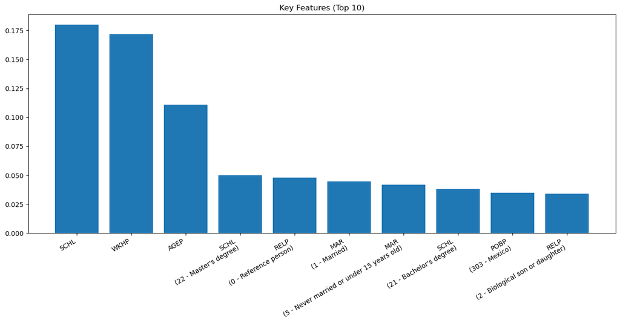

```python
# How many trees?
print(f'Number of trees: \t{pipe_rf.named_steps['model'].n_estimators}')

# Key Features?
kf_rf = pipe_rf.named_steps['model'].feature_importances_
#print(kf_rf)

# Fraction of trees splitting on age at root
tree_list = pipe_rf.named_steps['model'].estimators_
root_node_list = [e.tree_.feature[0] for e in tree_list]
col_list = np.array([c.split('__')[1] for c in pipe_rf.named_steps['preprocessing'].get_feature_names_out()])
age_share = np.sum(col_list[root_node_list] == 'AGEP')/col_list.shape[0]
print(f'Share w/ root `AGEP`: \t{age_share:.2%}')

# Create a plot showing the 10 most important features and compare them to the results you obtained before.
kf_rf_top10_idx = np.argsort(kf_rf)[::-1][0:10] # <-- reversed
kf_rf_top10 = kf_rf[kf_rf_top10_idx]

# Write a function to label the categorical feats correctly <--- Note: can probably put this in ColumnTransformer
def apply_label(feat_label):
    feat_split = feat_label.split('_')

    if(len(feat_split) == 1):
        return feat_label
    if(len(feat_split) == 2):
        cat_idx = int(float(feat_split[1]))
        cat_label = categories[feat_split[0]][cat_idx]
        return f'{feat_split[0]}\n({cat_idx} - {cat_label})'

kf_rf_top10__labels = [apply_label(s) for s in col_list[kf_rf_top10_idx]]

plt.figure(figsize=(16,6))
plt.bar(np.arange(0,10), kf_rf_top10)
plt.xticks(np.arange(0,10), kf_rf_top10__labels, rotation = 30, ha='right')
plt.title('Key Features (Top 10)')
plt.plot()
```

*your answer here*

**Explain the meaning of variable importance in the case of a random forest**

Variable imporance in the context of random forest is a measure of how frequently and how powerful each feature is across all trees included in the forest.

Schooling and working hours are the most valuable differentiator as far as predicting income is concerned. Next up is age.

### 3.2 Estimating AUC using K-fold CV

Calculate the 5-fold cross-validated AUC-ROC for the random forests pipeline. Report the score for each fold as well as the average across all folds.

**Hint 1**: sklearn.model_selection.cross_val_score is your friend. Setting the verbose option to 3 is useful.

```python
# your code here

# cv = KFold(n_splits=5, shuffle=True, random_state=0)
AUCs_cv_rf = cross_val_score(
    pipe_rf,
    X_train,
    y_train,
    cv=cv,
    scoring='roc_auc',
    verbose=2,
    n_jobs=-1
)

print('AUC for all folds:')
print(AUCs_cv_rf)
print(f'\nMean AUC: {np.mean(AUCs_cv_rf):.3f}\n')
```

```
[Parallel(n_jobs=-1)]: Using backend LokyBackend with 10 concurrent workers.
```

```
[CV] END .................................................... total time=   9.9s
[CV] END .................................................... total time=  10.1s
[CV] END .................................................... total time=  10.2s
[CV] END .................................................... total time=  10.2s
[CV] END .................................................... total time=  10.3s
AUC for all folds:
[0.87243924 0.87112891 0.87471254 0.87031427 0.87507136]

Mean AUC: 0.873
```

```
[Parallel(n_jobs=-1)]: Done   5 out of   5 | elapsed:   10.4s finished
```

### 3.3 Estimating AUC using nested CV

Let's try to improve on the results of the random forest by tweaking its hyperparameters. Build a pipeline that computes the nested cv AUC-ROC. Include different values for "n_estimators", "max_samples","max_features", "max_depth" and "max_leaf_nodes" in your hyperparameter grid. Report the inner and outer fold scores for all combinations of hyperparams and interpret the results. Report the best hyperparams used in each outer fold.

What do you notice about these results? How are these results related to those from the decision tree pipeline? Is hyperparameter optimization worth the trouble?

**Hint 1**: The pipeline remains the same. You can acces the list of all the hyperparams in your pipeline with pipeline.get_params_keys(). Notice the naming convention.

**Hint 2**: GridSearchCV and cross_val_score are your friends. Specially if you run them with verbose = 3.

**Hint 3**: This gets computationally expensive quickly. Be intelligent about the hyperparam values you include in the grid.

```python
from sklearn.model_selection import GridSearchCV

# your code here
outer_k, inner_k = 3, 5

inner_cv_rf = KFold(n_splits=inner_k, shuffle=True, random_state=0)
outer_cv_rf = KFold(n_splits=outer_k, shuffle=True, random_state=0)

#pipe_rf.get_params()['preprocessing'].get_params()
#pipe_rf.get_params()['decision_tree'].get_params()

# Parameter space to search
param_grid_rf = {
    'model__n_estimators': [50, 100], # x2
    'model__max_samples': [None, 10], # x2
    'model__max_depth': [3, 15], # x2
    'model__max_features': [25, 100], # x2
    'model__max_leaf_nodes': [100, 500] # x2
}
```

```python
#import logging
X_fold = X_train
y_fold = y_train.values

outer_scores_rf = []
for outer_train_idx, outer_test_idx in outer_cv_rf.split(X_fold):
    X_outer_train, X_outer_test = X_fold.iloc[outer_train_idx], X_fold.iloc[outer_test_idx]
    y_outer_train, y_outer_test = y_fold[outer_train_idx], y_fold[outer_test_idx]

    # Define Grid Search Object - uses all the params in `param_grid` to fit the `decision_tree` model
    grid_search_rf = GridSearchCV(
        estimator=pipe_rf,
        param_grid=param_grid_rf,
        cv=inner_cv,
        verbose=3,
        scoring='roc_auc',
        n_jobs=-1
    )

    # Fit Model across all hyper-parameters
    grid_search_rf.fit(X_outer_train, y_outer_train)

    inner_scores_rf = grid_search_rf.cv_results_

    outer_scores_rf.append(inner_scores_rf)
```

```
Fitting 5 folds for each of 32 candidates, totalling 160 fits
[CV 4/5] END model__max_depth=3, model__max_features=25, model__max_leaf_nodes=100, model__max_samples=None, model__n_estimators=50;, score=0.840 total time=   0.8s
[CV 3/5] END model__max_depth=3, model__max_features=25, model__max_leaf_nodes=100, model__max_samples=None, model__n_estimators=50;, score=0.840 total time=   0.8s
[CV 5/5] END model__max_depth=3, model__max_features=25, model__max_leaf_nodes=100, model__max_samples=None, model__n_estimators=50;, score=0.836 total time=   0.8s
[CV 1/5] END model__max_depth=3, model__max_features=25, model__max_leaf_nodes=100, model__max_samples=None, model__n_estimators=50;, score=0.844 total time=   0.9s
[CV 2/5] END model__max_depth=3, model__max_features=25, model__max_leaf_nodes=100, model__max_samples=None, model__n_estimators=50;, score=0.840 total time=   0.9s
[CV 4/5] END model__max_depth=3, model__max_features=25, model__max_leaf_nodes=100, model__max_samples=10, model__n_estimators=50;, score=0.822 total time=   0.5s
[CV 2/5] END model__max_depth=3, model__max_features=25, model__max_leaf_nodes=100, model__max_samples=10, model__n_estimators=50;, score=0.823 total time=   0.5s
[CV 3/5] END model__max_depth=3, model__max_features=25, model__max_leaf_nodes=100, model__max_samples=10, model__n_estimators=50;, score=0.811 total time=   0.5s
[CV 1/5] END model__max_depth=3, model__max_features=25, model__max_leaf_nodes=100, model__max_samples=10, model__n_estimators=50;, score=0.819 total time=   0.6s
[CV 5/5] END model__max_depth=3, model__max_features=25, model__max_leaf_nodes=100, model__max_samples=10, model__n_estimators=50;, score=0.818 total time=   0.5s
[CV 1/5] END model__max_depth=3, model__max_features=25, model__max_leaf_nodes=100, model__max_samples=None, model__n_estimators=100;, score=0.849 total time=   1.6s
[CV 3/5] END model__max_depth=3, model__max_features=25, model__max_leaf_nodes=100, model__max_samples=None, model__n_estimators=100;, score=0.845 total time=   1.6s
[CV 5/5] END model__max_depth=3, model__max_features=25, model__max_leaf_nodes=100, model__max_samples=None, model__n_estimators=100;, score=0.842 total time=   1.6s
[CV 4/5] END model__max_depth=3, model__max_features=25, model__max_leaf_nodes=100, model__max_samples=None, model__n_estimators=100;, score=0.848 total time=   1.6s
[CV 2/5] END model__max_depth=3, model__max_features=25, model__max_leaf_nodes=100, model__max_samples=None, model__n_estimators=100;, score=0.845 total time=   2.0s
[CV 1/5] END model__max_depth=3, model__max_features=25, model__max_leaf_nodes=100, model__max_samples=10, model__n_estimators=100;, score=0.828 total time=   0.9s
[CV 3/5] END model__max_depth=3, model__max_features=25, model__max_leaf_nodes=100, model__max_samples=10, model__n_estimators=100;, score=0.822 total time=   0.8s
[CV 2/5] END model__max_depth=3, model__max_features=25, model__max_leaf_nodes=100, model__max_samples=10, model__n_estimators=100;, score=0.835 total time=   0.9s
[CV 4/5] END model__max_depth=3, model__max_features=25, model__max_leaf_nodes=100, model__max_samples=10, model__n_estimators=100;, score=0.829 total time=   0.9s
[CV 5/5] END model__max_depth=3, model__max_features=25, model__max_leaf_nodes=100, model__max_samples=10, model__n_estimators=100;, score=0.824 total time=   0.9s
[CV 1/5] END model__max_depth=3, model__max_features=25, model__max_leaf_nodes=500, model__max_samples=None, model__n_estimators=50;, score=0.844 total time=   0.9s
[CV 3/5] END model__max_depth=3, model__max_features=25, model__max_leaf_nodes=500, model__max_samples=None, model__n_estimators=50;, score=0.840 total time=   0.8s
[CV 2/5] END model__max_depth=3, model__max_features=25, model__max_leaf_nodes=500, model__max_samples=None, model__n_estimators=50;, score=0.840 total time=   0.9s
[CV 4/5] END model__max_depth=3, model__max_features=25, model__max_leaf_nodes=500, model__max_samples=None, model__n_estimators=50;, score=0.840 total time=   0.9s
[CV 1/5] END model__max_depth=3, model__max_features=25, model__max_leaf_nodes=500, model__max_samples=10, model__n_estimators=50;, score=0.819 total time=   0.5s
```

[output cut: 457 more lines]

```python
# Print all
for i in range(0, outer_k):
    for mean_score, params in zip(outer_scores_rf[i]['mean_test_score'], outer_scores_rf[i]['params']):
        print(f"outer_fold: {i} -- Mean CV Score: {mean_score:.3f} with Parameters: {params}")
```

```
outer_fold: 0 -- Mean CV Score: 0.840 with Parameters: {'model__max_depth': 3, 'model__max_features': 25, 'model__max_leaf_nodes': 100, 'model__max_samples': None, 'model__n_estimators': 50}
outer_fold: 0 -- Mean CV Score: 0.846 with Parameters: {'model__max_depth': 3, 'model__max_features': 25, 'model__max_leaf_nodes': 100, 'model__max_samples': None, 'model__n_estimators': 100}
outer_fold: 0 -- Mean CV Score: 0.819 with Parameters: {'model__max_depth': 3, 'model__max_features': 25, 'model__max_leaf_nodes': 100, 'model__max_samples': 10, 'model__n_estimators': 50}
outer_fold: 0 -- Mean CV Score: 0.828 with Parameters: {'model__max_depth': 3, 'model__max_features': 25, 'model__max_leaf_nodes': 100, 'model__max_samples': 10, 'model__n_estimators': 100}
outer_fold: 0 -- Mean CV Score: 0.840 with Parameters: {'model__max_depth': 3, 'model__max_features': 25, 'model__max_leaf_nodes': 500, 'model__max_samples': None, 'model__n_estimators': 50}
outer_fold: 0 -- Mean CV Score: 0.846 with Parameters: {'model__max_depth': 3, 'model__max_features': 25, 'model__max_leaf_nodes': 500, 'model__max_samples': None, 'model__n_estimators': 100}
outer_fold: 0 -- Mean CV Score: 0.819 with Parameters: {'model__max_depth': 3, 'model__max_features': 25, 'model__max_leaf_nodes': 500, 'model__max_samples': 10, 'model__n_estimators': 50}
outer_fold: 0 -- Mean CV Score: 0.828 with Parameters: {'model__max_depth': 3, 'model__max_features': 25, 'model__max_leaf_nodes': 500, 'model__max_samples': 10, 'model__n_estimators': 100}
outer_fold: 0 -- Mean CV Score: 0.848 with Parameters: {'model__max_depth': 3, 'model__max_features': 100, 'model__max_leaf_nodes': 100, 'model__max_samples': None, 'model__n_estimators': 50}
outer_fold: 0 -- Mean CV Score: 0.847 with Parameters: {'model__max_depth': 3, 'model__max_features': 100, 'model__max_leaf_nodes': 100, 'model__max_samples': None, 'model__n_estimators': 100}
outer_fold: 0 -- Mean CV Score: 0.834 with Parameters: {'model__max_depth': 3, 'model__max_features': 100, 'model__max_leaf_nodes': 100, 'model__max_samples': 10, 'model__n_estimators': 50}
outer_fold: 0 -- Mean CV Score: 0.843 with Parameters: {'model__max_depth': 3, 'model__max_features': 100, 'model__max_leaf_nodes': 100, 'model__max_samples': 10, 'model__n_estimators': 100}
outer_fold: 0 -- Mean CV Score: 0.848 with Parameters: {'model__max_depth': 3, 'model__max_features': 100, 'model__max_leaf_nodes': 500, 'model__max_samples': None, 'model__n_estimators': 50}
outer_fold: 0 -- Mean CV Score: 0.847 with Parameters: {'model__max_depth': 3, 'model__max_features': 100, 'model__max_leaf_nodes': 500, 'model__max_samples': None, 'model__n_estimators': 100}
outer_fold: 0 -- Mean CV Score: 0.834 with Parameters: {'model__max_depth': 3, 'model__max_features': 100, 'model__max_leaf_nodes': 500, 'model__max_samples': 10, 'model__n_estimators': 50}
outer_fold: 0 -- Mean CV Score: 0.843 with Parameters: {'model__max_depth': 3, 'model__max_features': 100, 'model__max_leaf_nodes': 500, 'model__max_samples': 10, 'model__n_estimators': 100}
outer_fold: 0 -- Mean CV Score: 0.868 with Parameters: {'model__max_depth': 15, 'model__max_features': 25, 'model__max_leaf_nodes': 100, 'model__max_samples': None, 'model__n_estimators': 50}
outer_fold: 0 -- Mean CV Score: 0.868 with Parameters: {'model__max_depth': 15, 'model__max_features': 25, 'model__max_leaf_nodes': 100, 'model__max_samples': None, 'model__n_estimators': 100}
outer_fold: 0 -- Mean CV Score: 0.816 with Parameters: {'model__max_depth': 15, 'model__max_features': 25, 'model__max_leaf_nodes': 100, 'model__max_samples': 10, 'model__n_estimators': 50}
outer_fold: 0 -- Mean CV Score: 0.828 with Parameters: {'model__max_depth': 15, 'model__max_features': 25, 'model__max_leaf_nodes': 100, 'model__max_samples': 10, 'model__n_estimators': 100}
outer_fold: 0 -- Mean CV Score: 0.873 with Parameters: {'model__max_depth': 15, 'model__max_features': 25, 'model__max_leaf_nodes': 500, 'model__max_samples': None, 'model__n_estimators': 50}
outer_fold: 0 -- Mean CV Score: 0.874 with Parameters: {'model__max_depth': 15, 'model__max_features': 25, 'model__max_leaf_nodes': 500, 'model__max_samples': None, 'model__n_estimators': 100}
outer_fold: 0 -- Mean CV Score: 0.816 with Parameters: {'model__max_depth': 15, 'model__max_features': 25, 'model__max_leaf_nodes': 500, 'model__max_samples': 10, 'model__n_estimators': 50}
outer_fold: 0 -- Mean CV Score: 0.828 with Parameters: {'model__max_depth': 15, 'model__max_features': 25, 'model__max_leaf_nodes': 500, 'model__max_samples': 10, 'model__n_estimators': 100}
outer_fold: 0 -- Mean CV Score: 0.873 with Parameters: {'model__max_depth': 15, 'model__max_features': 100, 'model__max_leaf_nodes': 100, 'model__max_samples': None, 'model__n_estimators': 50}
outer_fold: 0 -- Mean CV Score: 0.873 with Parameters: {'model__max_depth': 15, 'model__max_features': 100, 'model__max_leaf_nodes': 100, 'model__max_samples': None, 'model__n_estimators': 100}
```

[output cut: 70 more lines]

```python
grid_search_rf.get_params().keys()

print('All scores:')
#print(np.array(outer_scores_rf))
#print(f'\nMean AUC: {np.mean(outer_scores_rf):.3f}')

outer_fold_print = [np.mean(i['mean_test_score']) for i in outer_scores_rf]
print(outer_fold_print)
print(f'total AUC: {np.mean(outer_fold_print):.3f}')
```

```
All scores:
[0.8448987252076575, 0.841040250950414, 0.838686462617982]
total AUC: 0.842
```

*your answer here*